# jina_ceiling_height_analysis

Jina Moon

2026-03-09

## Load Libraries

##read data

##Separate date column (DONE BY MICK)

```r
birds <- birds %>% separate(col="date", into = c("month","day","year"), sep = "/", remove = F) %>% ##separate month into col
  select(!day) %>% ##remove day, since data already has a day col
  mutate(month=as.factor(month)) ##make month into a factor
```

##Add season variable (DONE BY MICK)

```r
birds <- birds %>% ##make a new column showing what season, since the data is split by spring or fall
  mutate(season=case_when(
    month=="4" | month=="5" | month=="6" ~ "spring",
    month=="8" | month=="9" | month=="10" | month=="11" ~ "fall",
    .default=NA
  ))
```

##Adding migration level variable based on the paper(DONE BY MICK)

```r
birds <- birds %>%
  mutate(migration_level= case_when( ##migration level from the paper
    season=="spring" & amt>=4 & amt<=1860 ~ "medium", ##946 is average migration for spring
    season=="fall" & amt>=9 & amt<=3420 ~ "medium", ##1690 is avg for fall
    season=="spring" & amt<=4 ~ "low", ##avg-1SD
    season=="fall" & amt<=9 ~ "low",
  season=="spring" & amt>=1860 ~ "high", ##avg+1SD
    season=="fall" & amt>=3420 ~ "high"
  ))
```

##Separate wind speed into low, med, high with same method as migration level: low<= avg-1SD, med<= avg+1SD, >= avg-1SD, high>=avg+1SD. I took the absolute value of the winds first, since negative wind is just the opposite direction of positive, and I want to compare strength, not direction (DONE BY MICK)

```r
birds %>%
  group_by(season) %>%
  mutate(uwind_abs=abs(uwind), vwind_abs=abs(vwind)) %>%
  summarise(mean(uwind_abs), sd(uwind_abs), mean(vwind_abs), sd(vwind_abs))
```

```
## # A tibble: 2 × 5
##   season `mean(uwind_abs)` `sd(uwind_abs)` `mean(vwind_abs)` `sd(vwind_abs)`
##   <chr>              <dbl>           <dbl>             <dbl>           <dbl>
## 1 fall                2.18            1.76              2.36            1.52
## 2 spring              2.46            2.13              2.65            1.59
```

```r
birds <- birds %>%
  mutate(uwind_abs=abs(uwind), vwind_abs=abs(vwind)) %>%
  mutate(uwind_level= case_when(
    season=="spring" & uwind_abs<= 2.457172-2.132746 ~"low",
    season=="fall" & uwind_abs<= 2.184764-1.760663 ~"low",
    season=="spring" & uwind_abs>= 2.457172+2.132746 ~"high",
    season=="fall" & uwind_abs>= 2.184764+1.760663 ~"high",
    season=="spring" & uwind_abs>= 2.457172-2.132746 & uwind<= 2.457172+2.132746 ~"medium",
    season=="fall" & uwind_abs>= 2.184764-1.760663 & uwind_abs<= 2.184764+1.760663 ~"medium",
  )) %>%
  mutate(vwind_level= case_when(
    season=="spring" & vwind_abs<= 2.648716-1.587146 ~"low",
    season=="fall" & vwind_abs<= 2.357720-1.516771 ~"low",
    season=="spring" & vwind_abs>= 2.648716+1.587146 ~"high",
    season=="fall" & vwind_abs>= 2.357720+1.516771 ~"high",
    season=="spring" & vwind_abs>= 2.648716-1.587146 & vwind<= 2.648716+1.587146 ~"medium",
    season=="fall" & vwind_abs>= 2.357720-1.516771 & vwind_abs<= 2.357720+1.516771 ~"medium",
  ))
```

##colors

```r
colors <- paletteer::palettes_d_names
```

```r
my_palette <- paletteer_d("ggsci::indigo_material")
my_palette
```

```
## <colors>
## #E8EAF6FF #C5CAE9FF #9FA8DAFF #7986CBFF #5C6BC0FF #3F51B5FF #3949ABFF #303F9FFF #283593FF #1A237EFF
```

##Ceiling height vs. collisions

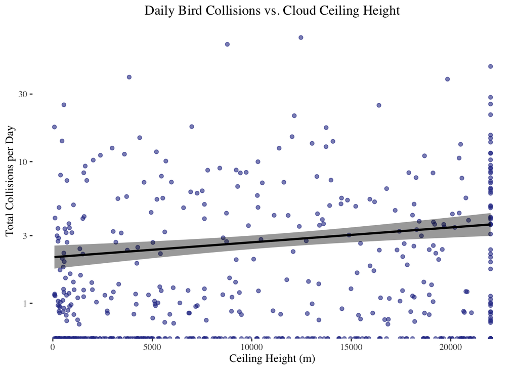

```r
birds %>%
  group_by(date, ceiling_height) %>% #grouped by date, so that we can look at date vs. ceiling_height and not other factors
  summarize(total_collisions = sum(count), .groups = "drop") %>%
  filter(total_collisions < 100) %>% #gets rid of one outlier that was identified for graph readability
  ggplot(aes(x = ceiling_height, y = total_collisions)) +
  geom_jitter(width = 0, height = 0.15, alpha = 0.6, color = "#283593FF") +
  geom_smooth(method = "lm", se = TRUE, linewidth = 1,color = "black", fill = "black") +
  scale_y_log10() +
  labs(
    title = "Daily Bird Collisions vs. Cloud Ceiling Height",
    x = "Ceiling Height (m)",
    y = "Total Collisions per Day"
  ) +
  theme_tufte() +
  theme(plot.title = element_text(size=rel(1.2), hjust = .5))
```

## Outlier?

```r
birds %>%
  group_by(date, ceiling_height) %>%
  summarize(total_collisions = sum(count), .groups = "drop") %>%
  arrange(desc(total_collisions)) %>%
  head(n = 5)
```

```
## # A tibble: 5 × 3
##   date       ceiling_height total_collisions
##   <chr>               <dbl>            <int>
## 1 9/14/2021          11915.              354
## 2 9/10/2021          12469.               97
## 3 10/15/2021          8771.               55
## 4 10/7/2021           3838.               51
## 5 9/19/2021          22000                36
```

```r
#one outlier at 354 collisions...
```

##Equal number of data for each building type? if unequal would influence total collisions per day (less buildings some days than other), buildings with fewer days look artificially safer, etc.

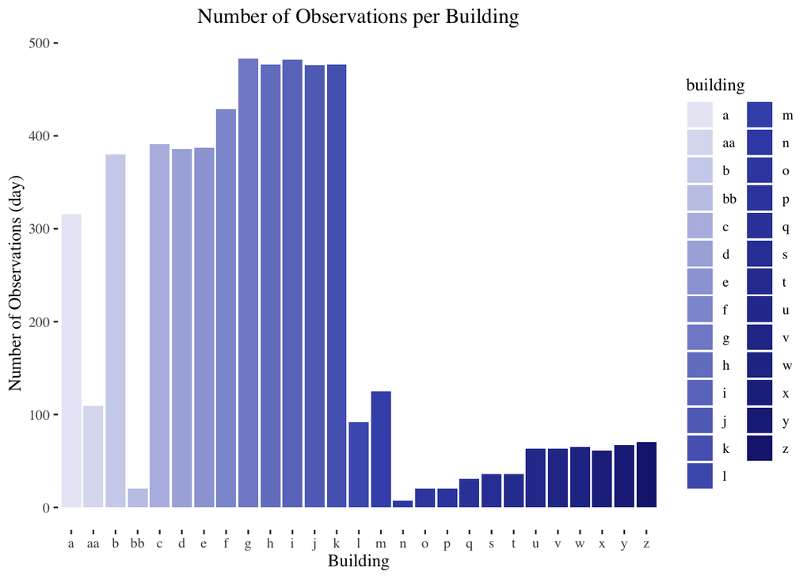

```r
birds %>%
  group_by(building) %>%
  count() %>%
  ggplot(aes(x=building, y=n)) +
  geom_col(mapping = aes (fill = building)) +
  labs(
    title = "Number of Observations per Building",
    x = "Building",
    y = "Number of Observations (day)"
  ) +
  theme_tufte() +
  theme(plot.title = element_text(size=rel(1.2), hjust = .5))+
  scale_fill_manual(values = colorRampPalette(my_palette)(27)) #using my palette, but let R fill in gaps
```

##BIG BIAS in observations for buildings…

```r
birds %>%
  group_by(building) %>%
  count() %>%
  arrange(desc(n))
```

```
## # A tibble: 27 × 2
## # Groups:   building [27]
##    building     n
##    <chr>    <int>
##  1 g          483
##  2 i          482
##  3 h          477
##  4 k          477
##  5 j          476
##  6 f          429
##  7 c          391
##  8 e          387
##  9 d          386
## 10 b          380
## # ℹ 17 more rows
```

g at 483 observations n at only 7 observations… Big thing to keep a look out for would really be making sure that the number of observations isn’t what impacts number of collisions…

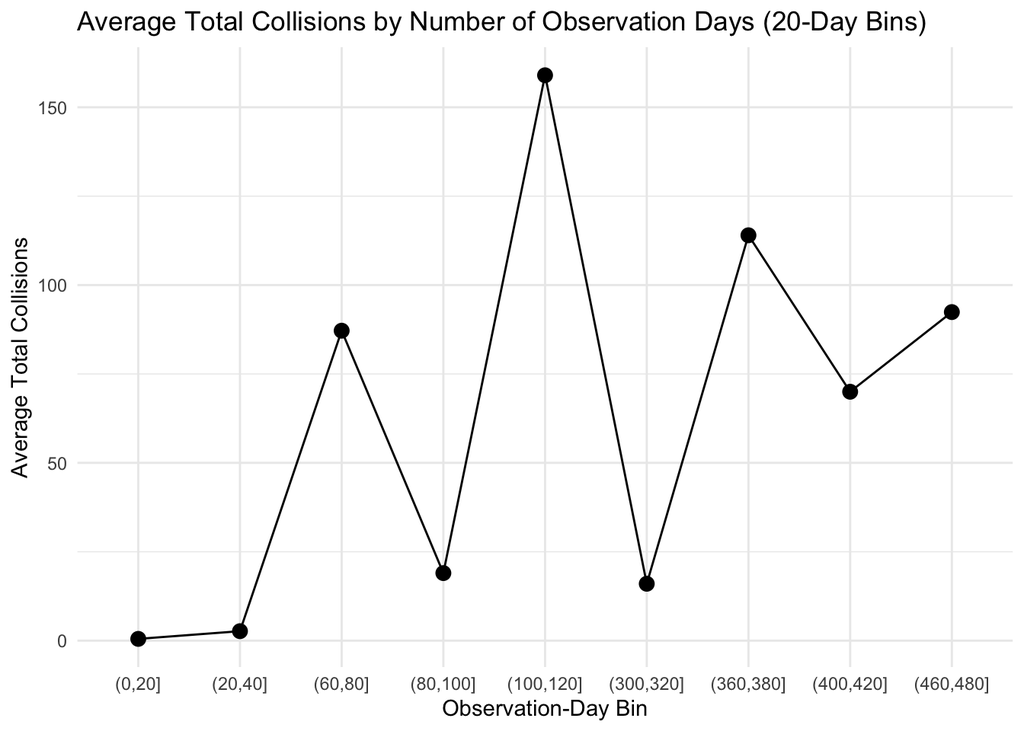

```r
building_observation_summary <- birds %>%
  group_by(building) %>%
  summarize(
    obs_days = n_distinct(date),
    total_collisions = sum(count),
    .groups = "drop"
  ) %>%  #we get total collisions and number of days the building was observed
  mutate(obs_bin = cut(obs_days, breaks = seq(0, 500, by = 20))) #seq is 0 to 500 since max n is 483


bin_calculations <- building_observation_summary %>%
  group_by(obs_bin) %>% #grouping by buildings that had certain amount of observations
  summarize(
    mean_collisions = mean(total_collisions), #average collisions for observation group it's in
    .groups = "drop"
  )


ggplot(bin_calculations, aes(x = obs_bin, y = mean_collisions, group = 1)) +
  geom_line() +
  geom_point(size = 3) +
  labs(
    title = "Average Total Collisions by Number of Observation Days (20-Day Bins)",
    x = "Observation-Day Bin",
    y = "Average Total Collisions"
  ) +
  theme_minimal()
```

##So basically we know not to do it by total collision, but need to use rate… I know I did one more later, with the total collisions by month and one by collision by observation, but we should combine

```r
birds %>%
  separate(date, into = c("month", "day", "year"), sep = "/", remove = FALSE) %>%
  mutate(month = factor(month, levels = as.character(1:12))) %>% #order
  group_by(month) %>%
  summarize(
    obs_days = n_distinct(date),
    total_collisions = sum(count),
    .groups = "drop"
  ) %>%
  mutate(mean_collisions = total_collisions / obs_days)
```

```
## # A tibble: 7 × 4
##   month obs_days total_collisions mean_collisions
##   <fct>    <int>            <int>           <dbl>
## 1 4          114               58          0.509
## 2 5          115              219          1.90
## 3 6           18                1          0.0556
## 4 8            1                2          2
## 5 9          129              888          6.88
## 6 10         140              578          4.13
## 7 11          43              128          2.98
```

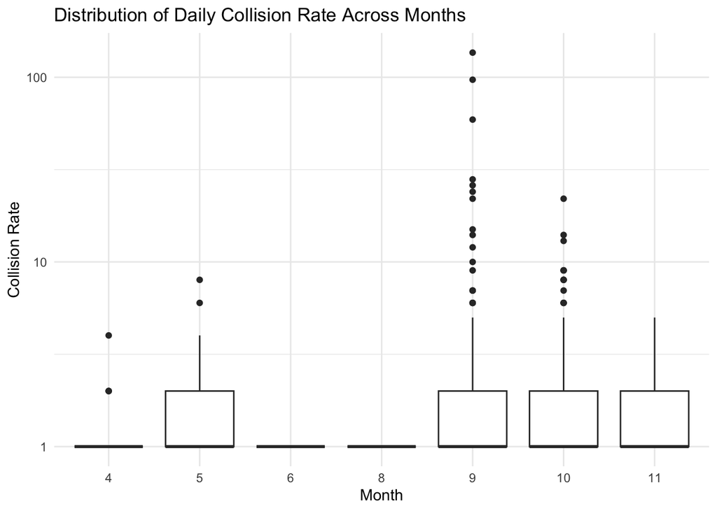

```r
birds_daily <- birds %>%
  separate(date, into = c("month", "day", "year"), sep = "/", remove = FALSE) %>%
  mutate(
    month = factor(month, levels = as.character(1:12)),
    )

ggplot(birds_daily, aes(x = month, y = count)) +
  geom_boxplot() +
  labs(
    title = "Distribution of Daily Collision Rate Across Months",
    x = "Month",
    y = "Collision Rate"
  ) +
  scale_y_log10() +
  theme_minimal()
```

```r
birds %>%
  filter(building == "n")
```

```
##        date month year yday building volunteer count     uwind      vwind
## 1  4/2/2021     4 2021   92        n       V13     0 5.7766284 -5.8949461
## 2  4/3/2021     4 2021   93        n       V93     0 3.1775610 -4.6715890
## 3  4/4/2021     4 2021   94        n       V70     0 1.2793995  0.9714432
## 4 4/18/2021     4 2021  108        n       V70     0 2.2546046 -2.6717499
## 5 4/26/2021     4 2021  116        n       V55     0 5.1228038 -5.9106128
## 6 5/17/2021     5 2021  137        n       V68     0 0.4793915  0.2680418
## 7 5/23/2021     5 2021  143        n       V42     0 3.5156014 -2.6670943
##   ceiling_height visibility_distance visibility temperature        amt
## 1       8730.417            16068.20       high    4.040000   6.024847
## 2      17450.615            16068.20       high    2.113333   5.702924
## 3       6073.364            16068.20       high    8.813333  16.456914
## 4       2009.000            16068.20       high   10.933333  13.437180
## 5      22000.000            16068.20       high   11.773333  15.008205
## 6      16410.727            16069.75       high   17.283333 480.341368
```

[output cut: 25 more lines]

… they really only had observations for building n for like… very few days…

okay so for for data, some buildings only had observations 7 times in a month, while others had observations 200 times in the month right. but if we are looking at ranges for collisions, most of the observations are 0, so the one with 200 observations would be more 0 oriented, while the one with 7 observations might be skewed due to not having 0 to bring it down..

##Collision rate by building count to tackle bias in different number of building observed per day

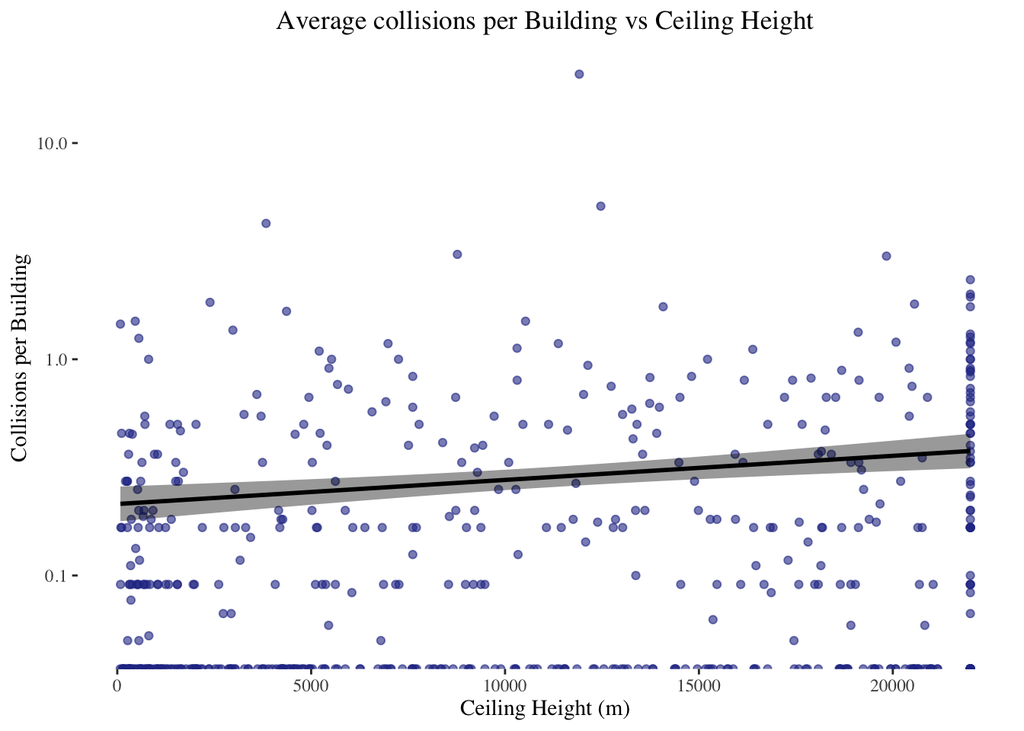

```r
birds %>%
  group_by(date, ceiling_height) %>%
  summarize(
    total_collisions = sum(count),
    n_buildings = n(),
    rate = total_collisions / n_buildings, #determines average rate of collisions each day, for the number of buildings observed
    .groups = "drop"
  ) %>%
  ggplot(aes(x = ceiling_height, y = rate)) +
  geom_point(alpha = 0.6, color = "#283593FF") +
  geom_smooth(method = "lm", se = TRUE, linewidth = 1, color = "black", fill = "black") +
  scale_y_log10() +
  labs(
    title = "Average collisions per Building vs Ceiling Height",
    x = "Ceiling Height (m)",
    y = "Collisions per Building"
  ) +
  theme_tufte() +
  theme(plot.title = element_text(size=rel(1.2), hjust = .5))
```

##Ceiling Height vs. Visibility Distance (do they go hand in hand?) Overall seems to be a correlation.

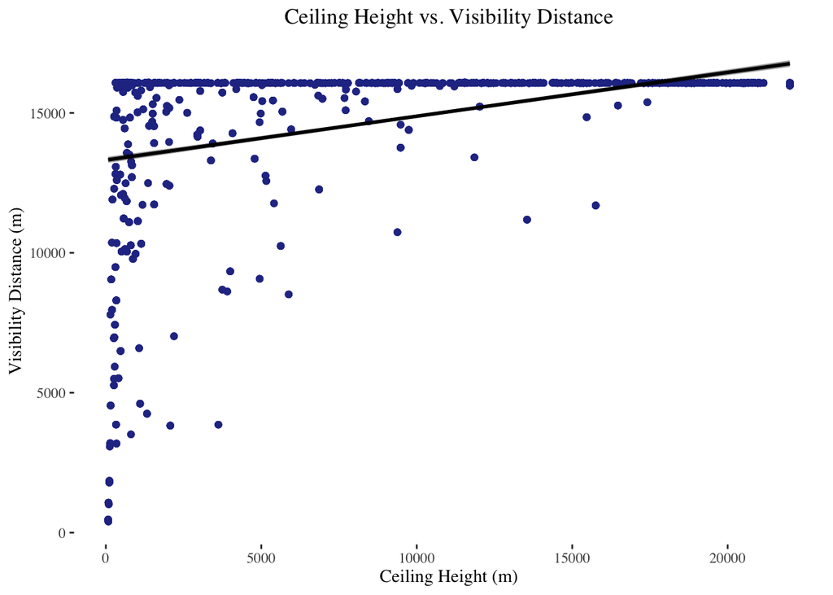

```r
#scatter plot
birds %>%
  ggplot(aes(x = ceiling_height, y = visibility_distance)) +
  geom_point(alpha = 0.6, color = "#283593FF") +
  geom_smooth(method = lm, se = TRUE, color = "black", fill = "black") +
  labs(
    title = "Ceiling Height vs. Visibility Distance",
    x = "Ceiling Height (m)",
    y = "Visibility Distance (m)"
  ) +
  theme_tufte() +
  theme(plot.title = element_text(size=rel(1.2), hjust = .5))
```

#Number of observations for each visibility type

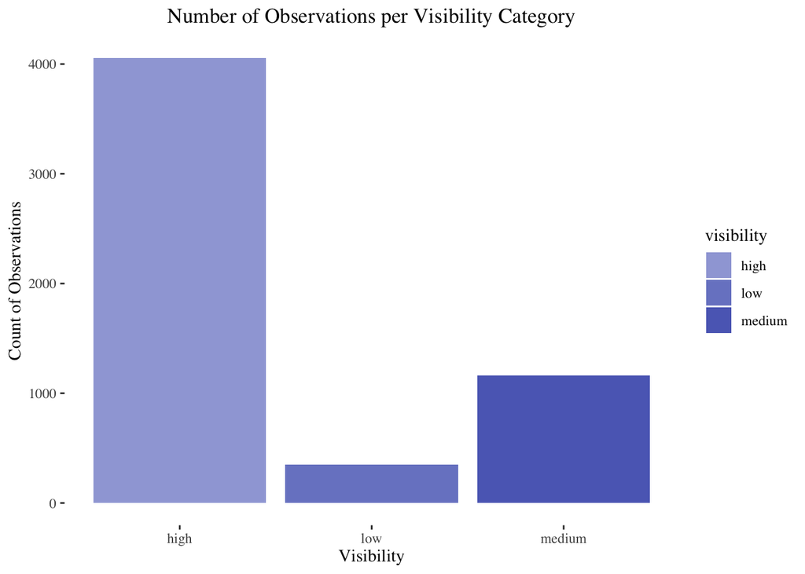

```r
birds %>%
  count(visibility) %>%
  ggplot(aes(x = visibility,  y = n, fill = visibility)) +
  geom_col() +
  labs(
    title = "Number of Observations per Visibility Category",
    x = "Visibility",
    y = "Count of Observations"
  )+
  theme_tufte() +
  theme(plot.title = element_text(size=rel(1.2), hjust = .5)) +
  scale_fill_manual(values=my_palette[3:10])
```

#Collision rate per observation for each visibiltiy factor (to tackle bias )

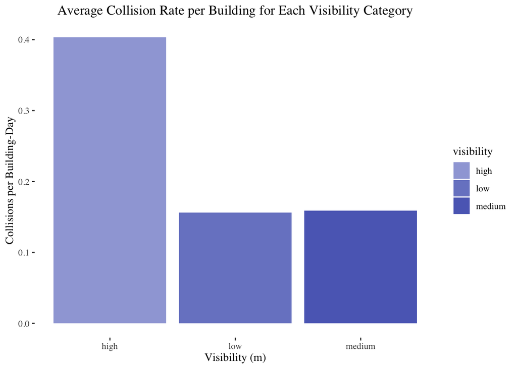

```r
birds %>%
  group_by(date, visibility) %>%
  summarize(
    total_collisions = sum(count),
    n_buildings = n(), #
    .groups = "drop"
  ) %>% #gives us number of buildings and total collisions per day
  group_by(visibility) %>%
  summarize(
    total_collisions = sum(total_collisions),
    total_buildings = sum(n_buildings),
    rate = total_collisions / total_buildings, #average collisions per building
    .groups = "drop"
  ) %>%
  ggplot(aes(x = factor(visibility), y = rate, fill = visibility)) +
  geom_col() +
  labs(
    title = "Average Collision Rate per Building for Each Visibility Category",
    x = "Visibility (m)",
    y = "Collisions per Building-Day"
  ) +
  theme_tufte() +
  theme(plot.title = element_text(size=rel(1.2), hjust = .5)) +
  scale_fill_manual(values=my_palette[3:10])
```

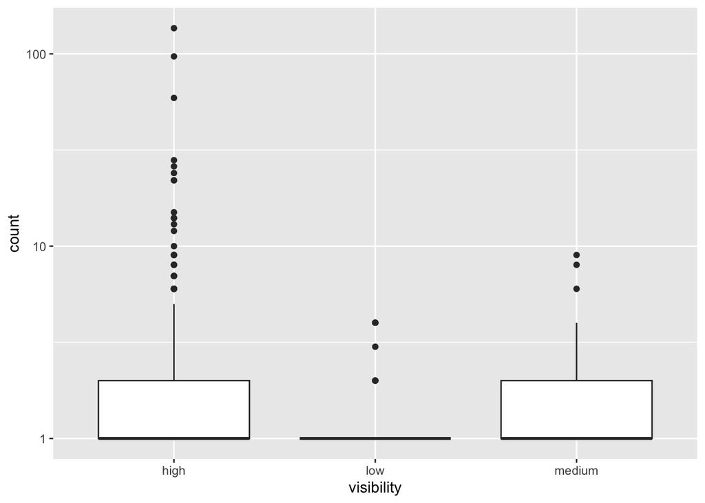

```r
birds%>%
  ggplot(aes(x=visibility, y=count))+
  geom_boxplot()+
  scale_y_log10()
```

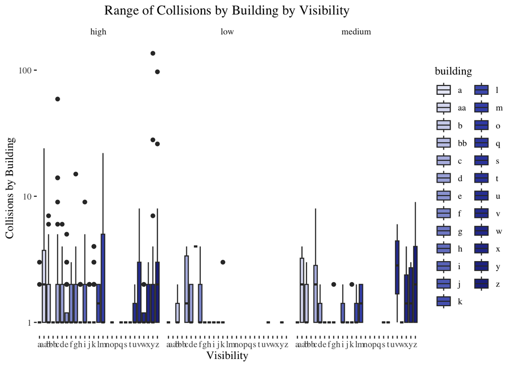

```r
birds%>%
  ggplot(aes(x=building, y=count))+
  geom_boxplot(aes(fill = building))+
  scale_y_log10()+
  facet_wrap(~visibility) +
  theme_tufte() +
  theme(plot.title = element_text(size=rel(1.2), hjust = .5)) +
  scale_fill_manual(values = colorRampPalette(my_palette)(27)) +
  labs(
    title = "Range of Collisions by Building by Visibility",
    x = "Visibility",
    y = "Collisions by Building"
  )
```

##maybe try making visbility without any outliers?

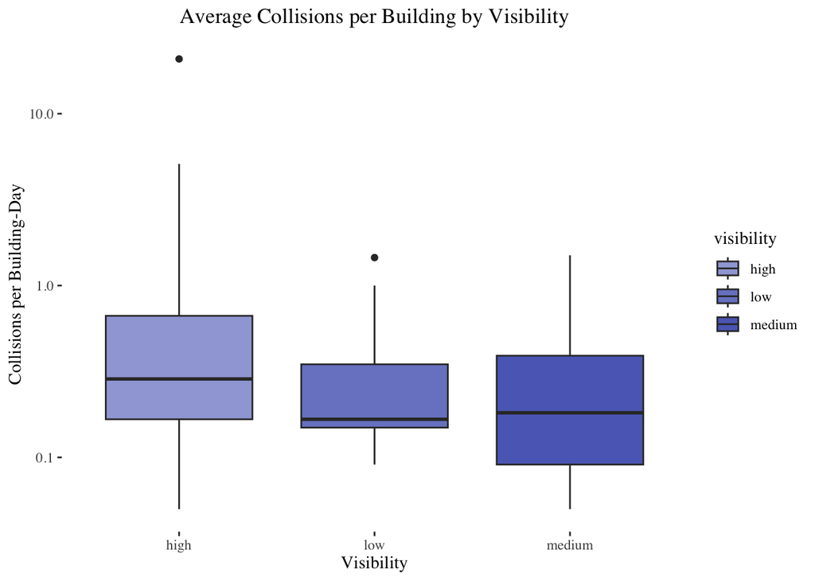

```r
birds %>%
  group_by(date, visibility) %>%
  summarize(
    total_collisions = sum(count),
    n_buildings = n(), #
    .groups = "drop"
  ) %>% #gives us number of buildings and total collisions per day
  mutate(avg_collisions_by_building_per_day = total_collisions / n_buildings) %>%
  ggplot(aes(x = visibility, y = avg_collisions_by_building_per_day)) +
  scale_y_log10() +
  geom_boxplot(mapping=aes(fill = visibility)) +
  labs(
    title = "Average Collisions per Building by Visibility",
    x = "Visibility",
    y = "Collisions per Building-Day"
  ) +
  theme_tufte() +
  theme(plot.title = element_text(size=rel(1.2), hjust = .5)) +
  scale_fill_manual(values=my_palette[3:10])
```

#cooked Kinda cooked cuz high visibility should have lower collision count…

```r
birds %>%
  count(visibility)
```

```
##   visibility    n
## 1       high 4053
## 2        low  352
## 3     medium 1164
```

maybe this is issue? no

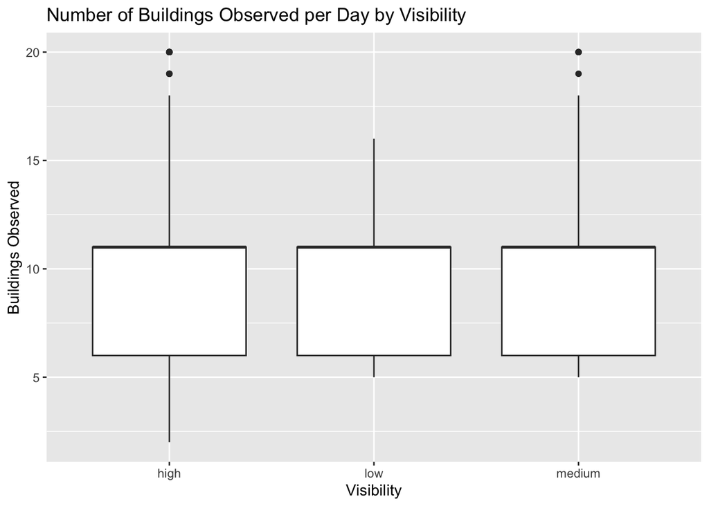

```r
birds %>%
  group_by(date, visibility) %>%
  summarize(n_buildings = n(), .groups = "drop") %>%
  ggplot(aes(x = visibility, y = n_buildings)) +
  geom_boxplot() +
  labs(
    title = "Number of Buildings Observed per Day by Visibility",
    x = "Visibility",
    y = "Buildings Observed"
  )
```

#okay lets look at migration

#check migration levels and visibiltiy

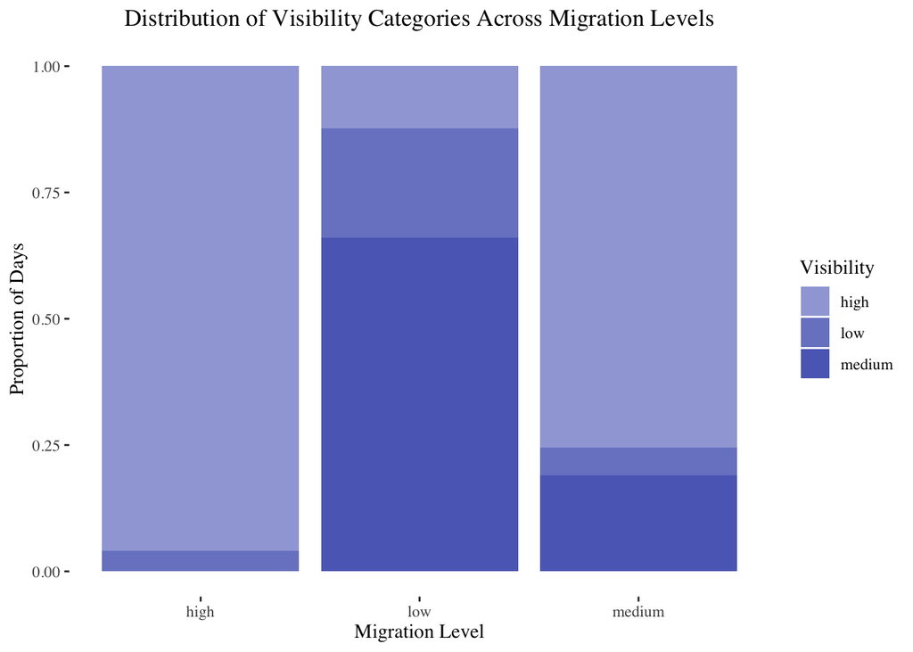

```r
birds %>%
  ggplot(aes(x = migration_level, fill = visibility)) +
  geom_bar(position = "fill") +
  labs(
    title = "Distribution of Visibility Categories Across Migration Levels",
    x = "Migration Level",
    y = "Proportion of Days",
    fill = "Visibility"
  ) +
  theme_tufte() +
  theme(plot.title = element_text(size = rel(1.2), hjust = .5)) +
  scale_fill_manual(values = my_palette[3:10])
```

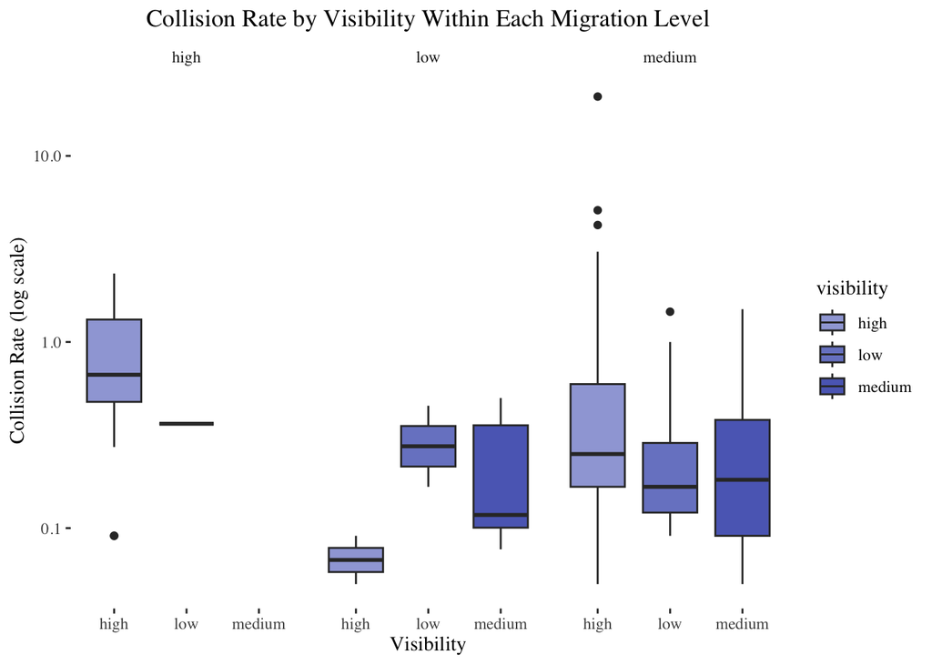

```r
birds %>%
  group_by(date, visibility, migration_level) %>%
  summarize(
    total_collisions = sum(count),
    n_buildings = n(),
    rate = total_collisions / n_buildings,
    .groups = "drop"
  ) %>%
  ggplot(aes(x = visibility, y = rate, fill = visibility)) +
  geom_boxplot() +
  scale_y_log10() +
  facet_wrap(~ migration_level) +
  labs(
    title = "Collision Rate by Visibility Within Each Migration Level",
    x = "Visibility",
    y = "Collision Rate (log scale)"
  ) +
  theme_tufte() +
  theme(plot.title = element_text(size = rel(1.2), hjust = .5)) +
  scale_fill_manual(values = my_palette[3:10])
```

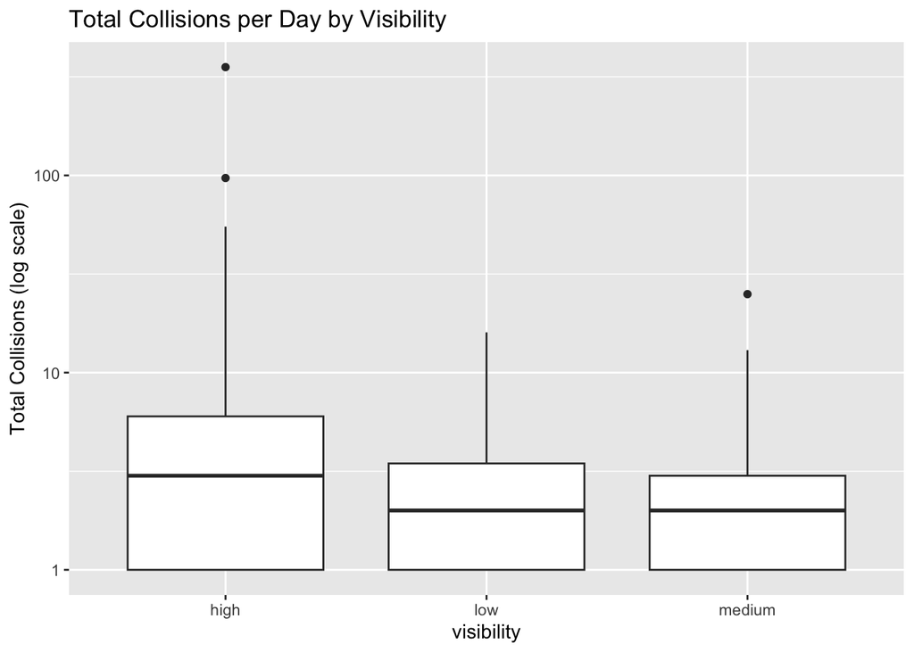

```r
daily_totals <- birds %>%
  group_by(date, visibility) %>%
  summarize(
    total_collisions = sum(count),
    .groups = "drop"
  )

ggplot(daily_totals, aes(x = visibility, y = total_collisions)) +
  geom_boxplot() +
  scale_y_log10() +
  labs(
    title = "Total Collisions per Day by Visibility",
    y = "Total Collisions (log scale)"
  )
```

#Collisions by month

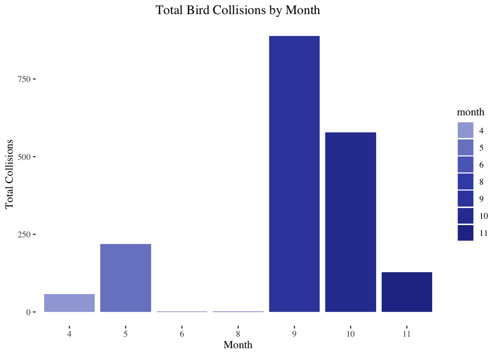

```r
birds %>%
  separate(date, into = c("month", "day", "year"), sep = "/", remove = FALSE) %>%
  mutate(month = factor(month, levels = as.character(1:12))) %>% #order
  group_by(month) %>%
  summarize(total_collisions = sum(count), .groups = "drop") %>%
  ggplot(aes(x = month, y = total_collisions, fill = month)) +
  geom_col() +
  labs(
    title = "Total Bird Collisions by Month",
    x = "Month",
    y = "Total Collisions"
  ) +
  theme_tufte() +
  theme(plot.title = element_text(size=rel(1.2), hjust = .5)) +
  scale_fill_manual(values=my_palette[3:10])
```

##is there a similar monthly trend every year in bird collision count ?

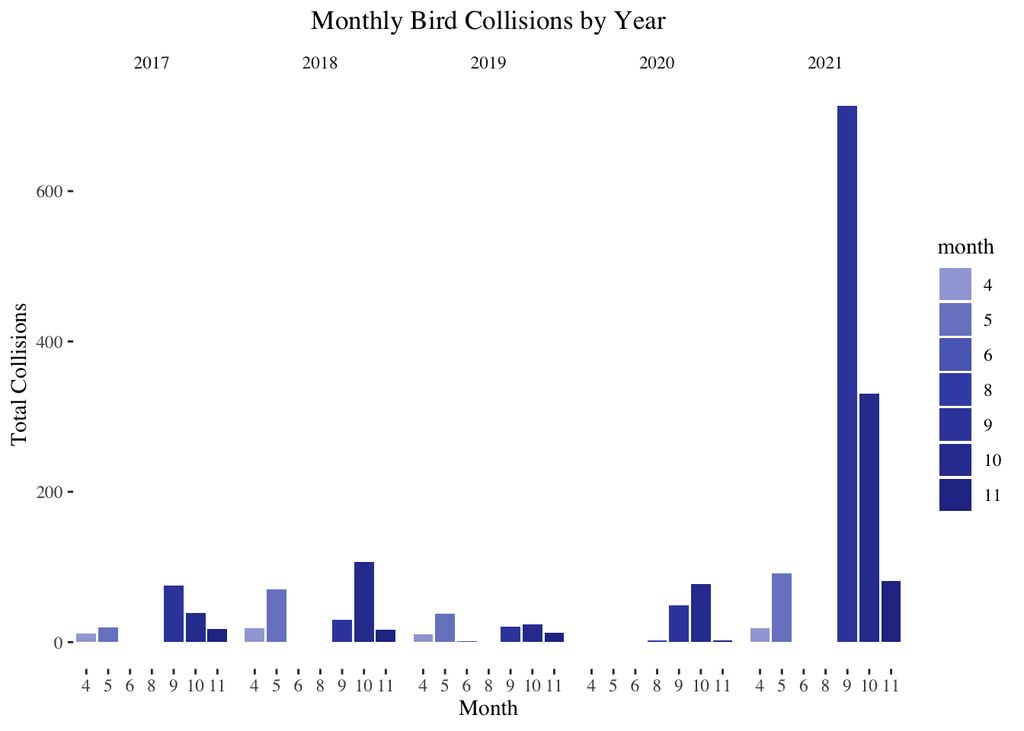

```r
birds %>%
  separate(col="date", into=c("month", "day", "year"), sep = "/") %>%
  select(year, month, count) %>%
  mutate(month = factor(month, levels = as.character(1:12))) %>%
  group_by(year, month) %>%
  summarize(monthly_collision = sum(count), .groups = "drop") %>%
  ggplot(aes(x = month, y = monthly_collision)) +
  geom_col(aes(fill = month)) +
  facet_grid(~year) +
  labs(
    title = "Monthly Bird Collisions by Year",
    x = "Month",
    y = "Total Collisions"
  )+
  theme_tufte() +
  theme(plot.title = element_text(size=rel(1.2), hjust = .5)) +
  scale_fill_manual(values=my_palette[3:10])
```

#Collisions by building

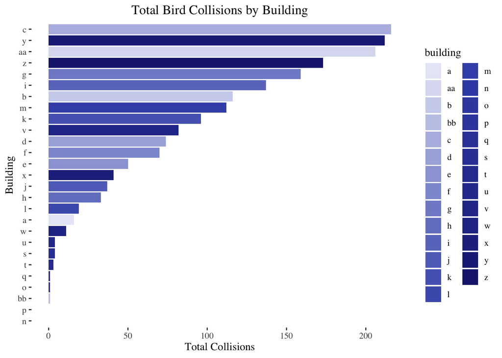

```r
birds %>%
  group_by(building) %>%
  summarize(total_collisions = sum(count), .groups = "drop") %>%
  ggplot(aes(x = reorder(building, total_collisions), y = total_collisions, fill = building)) +
  geom_col() +
  labs(
    title = "Total Bird Collisions by Building",
    x = "Building",
    y = "Total Collisions"
  ) +
  coord_flip() +
  theme_tufte() +
  theme(plot.title = element_text(size=rel(1.2), hjust = .5)) +
  scale_fill_manual(values = colorRampPalette(my_palette)(27))
```

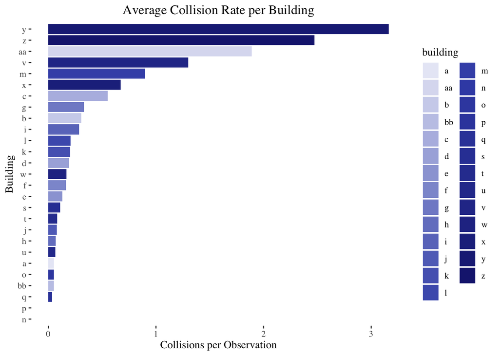

```r
birds %>%
  group_by(building) %>%
  summarize(
    total_collisions = sum(count),
    n_obs = n(),   # number of building-day observations
    rate = total_collisions / n_obs,
    .groups = "drop"
  ) %>%
  ggplot(aes(x = reorder(building, rate), y = rate, fill = building)) +
  geom_col() +
  labs(
    title = "Average Collision Rate per Building",
    x = "Building",
    y = "Collisions per Observation"
  ) +
  coord_flip() +
  theme_tufte() +
  theme(plot.title = element_text(size=rel(1.2), hjust = .5)) +
  scale_fill_manual(values = colorRampPalette(my_palette)(27))
```

## Number of observations by volunteers

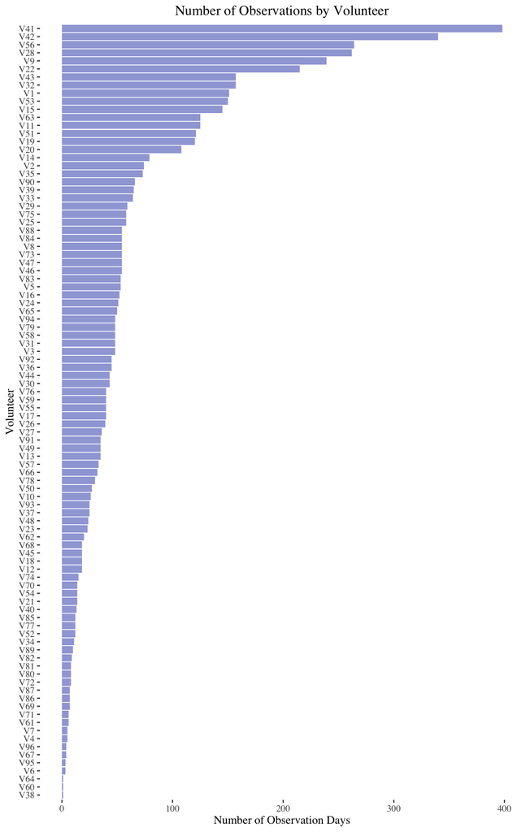

```r
birds %>%
  group_by(volunteer) %>%
  summarize(
    n_obs = n(),
    .groups = "drop"
  ) %>%
  ggplot(aes(x = reorder(volunteer, n_obs), y = n_obs)) +
  geom_col(fill = "#9FA8DAFF") +
  coord_flip() +
  labs(
    title = "Number of Observations by Volunteer",
    x = "Volunteer",
    y = "Number of Observation Days"
  ) +
  theme_classic() +
  theme(
    axis.text.y = element_text(size = 6)  # shrink labels so they don't overlap
  ) +
  theme_tufte() +
  theme(plot.title = element_text(size=rel(1.2), hjust = .5))
```

##volunteers?

```
## ℹ Adding new coordinate system, which will replace the existing one.
```

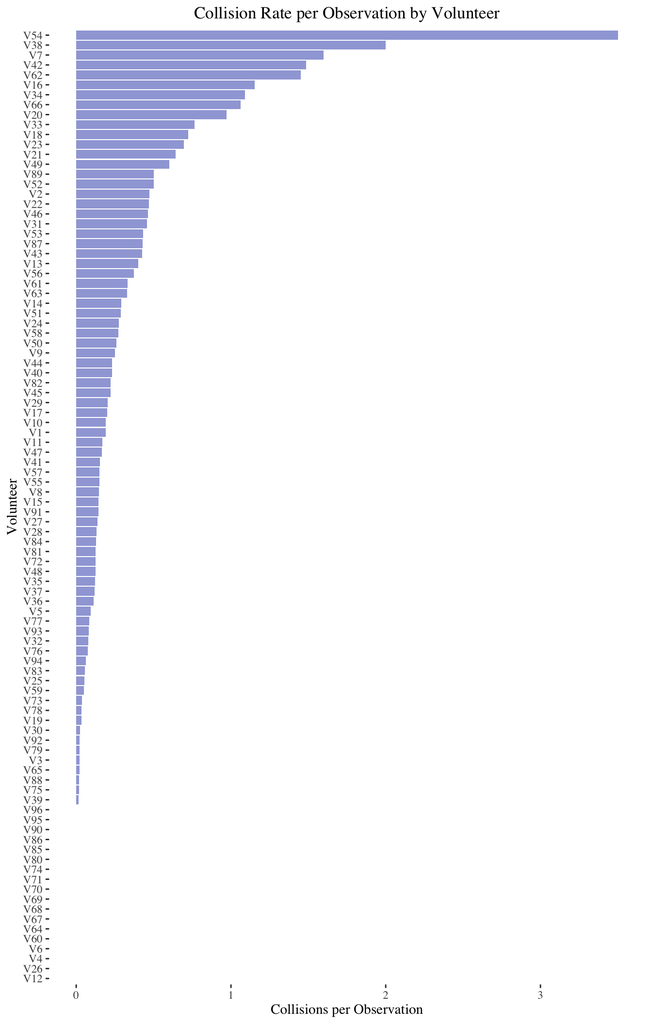

```r
birds %>%
  group_by(volunteer) %>%
  summarize(
    total_collisions = sum(count),
    n_obs = n(),
    rate = total_collisions / n_obs,
    .groups = "drop"
  ) %>%
  ggplot(aes(x = reorder(volunteer, rate), y = rate)) +
  geom_col(fill = "#9FA8DAFF") +
  coord_flip() +
  labs(
    title = "Collision Rate per Observation by Volunteer",
    x = "Volunteer",
    y = "Collisions per Observation"
  ) +
  theme_tufte() +
  coord_flip() +
  theme(plot.title = element_text(size=rel(1.2), hjust = .5))
```

##Volunteer with highest collisions per Observation Top volunteer matches top months with collisions so seasonal effect (less volunteer effect)

```r
#Identifying top volunteer
top_volunteer <- birds %>%
  group_by(volunteer) %>%
  summarize(
    total_collisions = sum(count),
    n_obs = n(),
    rate = total_collisions / n_obs,
    .groups = "drop"
  ) %>%
  arrange(desc(rate)) %>%
  head(n = 1)
```

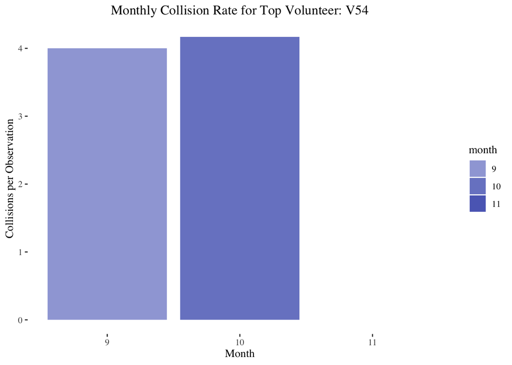

```r
birds %>%
  separate(date, into = c("month","day","year"), sep = "/") %>%
  filter(volunteer == top_volunteer$volunteer) %>%
  group_by(month) %>%
  mutate(
    month = factor(month, levels = as.character(1:12)) #order month
  ) %>%
  summarize(
    n_obs = n(),                     # number of surveys they did in each month
    total_collisions = sum(count),   # total collisions they found in each month
    rate = total_collisions / n_obs  # collisions per observation in each month
  ) %>%
  ggplot(aes(x = month, y = rate, fill = month)) +
  geom_col() +
  labs(
    title = paste("Monthly Collision Rate for Top Volunteer:", top_volunteer$volunteer),
    x = "Month",
    y = "Collisions per Observation"
  ) +
  theme_tufte() +
  theme(plot.title = element_text(size=rel(1.2), hjust = .5)) +
  scale_fill_manual(values=my_palette[3:10])
```

##Making sure there isn’t month bias… observation by month Survey effort not evenly distributed across months, with much more observations during spring and fall migration periods. This uneven sampling effort may inflate apparent seasonal collision patterns, making it difficult to distinguish true biological seasonality from survey bias.

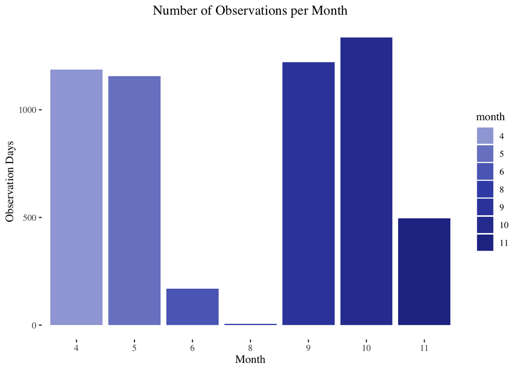

```r
birds %>%
  separate(date, into = c("month","day","year"), sep = "/") %>%
  mutate(
    month = factor(month, levels = as.character(1:12)) #order month
  ) %>%
  count(month) %>%
  ggplot(aes(x = month, y = n, fill = month)) +
  geom_col() +
  labs(
    title = "Number of Observations per Month",
    x = "Month",
    y = "Observation Days"
  ) +
  theme_tufte() +
  theme(plot.title = element_text(size=rel(1.2), hjust = .5)) +
  scale_fill_manual(values=my_palette[3:10])
```